# Assignment1

John Lin

Question1 (a)

$$\mu = \int_{[0,1)^3}f(\vec{u})d\vec{u}\\
=\int_{u_1}\int_{u_2}\int_{u_3}u_1^2+cos(2\pi u_2)+2u_3du_3du_2du_1\\
=\int_{u_1}\int_{u_2}u_1^2u_3+cos(2\pi u_2)u_3+u_3^2|_0^1du_2du_1\\
=\int_{u_1}\int_{u_2}u_1^2+cos(2\pi u_2)+1du_2du_1\\
=\int_{u_1}u_1^2u_2+\frac{1}{2\pi}sin(2\pi u_2)+u_2|_0^1du
_1\\
=\int_{u_1}u_1^2+1du_1=\frac{u_1^3}{3}+u_1|_0^1=\frac{4}{3}$$

2. From part a, we obtain the $\mu = \frac{4}{3}$. We will obtain $\hat{\mu}$ value by using Monte Carol method and multivariate trapezoidal rule.

```r
n <- 1000
N <- 9
s <- 3 # 3 dimension
mu <- 4/3
MC <- function(n){
  u1 <- runif(n,0,1)
  u2 <- runif(n,0,1)
  u3 <- runif(n,0,1)
  U <- f(u1,u2,u3)
  u_mc = sum(U)/n
  return(u_mc)
}
MT <- function(N,s){
  n = (N+1)^s
  u1 <- runif(n,0,1)
  u2 <- runif(n,0,1)
  u3 <- runif(n,0,1)
  U <- f(u1,u2,u3)
  w <- array(0, c(N+1,N+1,N+1))
  for (i in 1:(N+1)){
    for (j in 1:(N+1)){
      for (k in 1:(N+1)){
        if(i >=2 && i <=N){v1 <- 1/N}
        else {v1 <- 1/(2*N)}
        if(j >=2 && j <=N){v2 <- 1/N}
        else {v2 <- 1/(2*N)}
        if(k >=2 && k <=N){v3 <- 1/N}
        else {v3 <- 1/(2*N)}
        w[i,j,k] <- v1*v2*v3
      }
    }
  }
  w <- array(w)
  u_mt = U*w
  return(sum(u_mt))
}
f <-function(u1,u2,u3){
  f <- u1^2 +cos(2*pi*u2) +2*u3
  return(f)
}
u_MC <- rep(0,2)
u_MT <- rep(0,2)
u_MC[1] <- MC(n)
u_MT[1] <- MT(N,s)

n <- 8000
N <- 19
s <- 3 # 3 dimension
u_MC[2] <- MC(n)
u_MT[2] <- MT(N,s)

error_MC <- abs(u_MC - mu)
error_MT <- abs(u_MT - mu)

c(u_MC,u_MT)
```

```
## [1] 1.343514 1.322982 1.326880 1.353906
```

```r
df <- data.frame(Method = c("MC n=1000","Multi Trap N = 9",
                       "MC n=8000","Multi Trap N = 19"),
                 mu_hat = c(u_MC[1],u_MT[1],u_MC[2],u_MT[2]),
                 abs_error= c(error_MC[1],error_MT[1],error_MC[2],error_MT[2]))
knitr::kable(df)
```

| Method | mu_hat | abs_error |
| --- | --- | --- |
| MC n=1000 | 1.343514 | 0.0101808 |
| Multi Trap N = 9 | 1.326880 | 0.0064530 |
| MC n=8000 | 1.322982 | 0.0103514 |
| Multi Trap N = 19 | 1.353906 | 0.0205728 |

```r
#c(u_MC,u_MT)
```

Question 2

1. To prove $H_n$ is an unbiased estimator of $I(f)$, we need to show $E[H_n] = I(f)$.

$$E[H_n] = E[\frac{1}{n}\sum_{i=1}^nw_i\times Vol(A) \times M]\\
=\frac{1}{n}\sum_{i=1}^{n}E[w_i]\times Vol(A)\times M\\
=\frac{1}{n}\sum_{i=1}^{n}P(f(u_i) > y_i)\times Vol(A) \times M, y_i\sim UNIF(0,M)\\
=\frac{1}{n}\sum_{i=1}^{n}P(f(u_i) > y_i)\times \int_A M d\vec{u}\\
=\frac{1}{n}\sum_{i=1}^{n}P(f(u_i) > y_i)\times\int_A\int_0^{M}1dy_idu_i\\
=\frac{1}{n}\sum_{i=1}^{n}1_{(f(u_i) > y_i)}\times\int_A\int_0^{M}1dy_idu_i\\
=\frac{1}{n}\sum_{i=1}^{n}\int_A\int_0^{f(u_i)}1dy_idu_i\\
=\frac{1}{n}\sum_{i=1}^{n}\int_Af(u_i)du_i = \int_Af(\vec{u})d\vec{u} = I(f)$$

```r
set.seed(906)
n <- 2500
M <- 1
A <- 1
u <- runif(n,0,A)
y <- runif(n,0,M)
f <-function(u){
  return(sqrt(1-u^2))
}

f_u <- f(u)
w <- rep(0,n)
w[f_u > y] <- 1

u_mc <- 1/n * sum(w) * M * A
sigma <- sqrt(sum((f_u - u_mc)^2)/(n-1))
CI <-c(u_mc - 1.96 * sigma/sqrt(n),u_mc + 1.96 * sigma/sqrt(n) ) # confidence interval
CI
```

```
## [1] 0.7783379 0.7960621
```

```r
half_width <- (CI[2]-CI[1])/2
half_width
```

```
## [1] 0.008862126
```

As shown above, the 95% confidence interval is [0.7783379 0.7960621].

3. Yes. We are able to avoid computing a square root as long as we make 2 changes in the algorithm. Firstly, we need to change the function $f(u)$ as $f(u) = 1-u^2$. Second, we need to change a bit on the $w_i$ as
   $$w_i = \begin{cases} 0 &f(u_i)\leq y_i^2 \\
   1 &otherwise \end{cases}$$
   The code is shown below, the 95% confidence interval is [0.7743805 0.8000195], which is very close to the confidence interval above.

```r
## part c
# change function f(u) = 1-u^2, and w_i = 1 when f(u) <=y^2.
f2 <- function(u){
  return(1-u^2)
}
f_u <- f2(u)
w <- rep(0,n)
w[f_u > y^2] <- 1

u_mc <- 1/n * sum(w) * M * A
sigma <- sqrt(sum((f_u - u_mc)^2)/(n-1))
CI <-c(u_mc - 1.96 * sigma/sqrt(n),u_mc + 1.96 * sigma/sqrt(n) ) # confidence interval
CI
```

```
## [1] 0.7743805 0.8000195
```

```r
half_width <- (CI[2]-CI[1])/2
half_width
```

```
## [1] 0.01281952
```

4. The 95% confidence interval is [0.7743805 0.8000195], and the half width of the interval is 0.01281952.
5. A simple comparsion is to choose M = 1, and thus A = 1 as well. For the hit-and-miss algorithm.
   $$Var[H_n] = \frac{1}{n^2}Vol(A)^2 M^2\sum_{i=1}^{n}Var(w_i), w_i \sim Bernoulli(\pi/4)\\
   =\frac{1}{n^2}\times n \times \pi/4 \times(1-\pi/4)\\
   =\frac{\pi(1-\pi)}{16n}$$
   As for Monte Carlo method, the variance is
   $$Var[\hat{\mu_{mc}}] = \frac{Var[f(u)]}{n} = \frac{E[f(u)^2] - E[f(u)]^2}{n}\\
   =\frac{1}{n}(\int_0^1
   (1 - u^2)du - \frac{\pi}{4}^2) \\
   = \frac{2}{3n} - \frac{\pi^2}{16n}$$

Question 3

1. From the lecture, we know that $Q_n = 0.5 + \frac{c}{n}\sum_{i=1}^{n}\frac{1}{\sqrt{2\pi}}e^{\frac{-(cu_i)^2}{2}}$, where $u_i \sim UNIF(0,1)$. Furthermore, we know that $R_n = \frac{1}{n}\sum_{i=1}^{n}1_{x_i<c}$, where $x_i \sim N(0,1)$.

$$Var[Q_n] = \frac{c^2}{2\pi n^2}\sum_{i=1}^{n}Var[e^-\frac{(cu_i)^2}{2}]\\
=\frac{c^2}{2\pi n}Var[e^-\frac{(cu_i)^2}{2}]\\
=\frac{c^2}{2\pi n}[E[e^{-(cu_i)^2}] - E[e^{-\frac{(cu_i)^2}{2}}]^2]\\
=\frac{c^2}{2\pi n}[\int_0^1e^{-(cu)^2} - (\int_0^1e^{-\frac{(cu_i)^2}{2}})^2]\\
=\frac{c^2}{2\pi n}[\frac{\sqrt{\pi}}{c}(\Phi(\sqrt{2}c) - 0.5)-\frac{2\pi}{c^2}(\Phi(c)-0.5)^2]$$

$$Var[R_n] = \frac{1}{n^2}\sum_{i=1}^{n}Var[1_{x_i<c}]\\
=\frac{1}{n^2}\times n[E[(1_{x_i<c})^2] - E[(1_{x_i<c})]^2]\\
=\frac{1}{n}(\Phi(c) - \Phi(c)^2)$$
(b)

```r
#set.seed(906)
n <-2500
R <- function(c,n){
  w <- rep(0,n)
  sum <- 0
  #n <- 2500
  x <- rnorm(n,mean = 0, sd = 1)
  w[x < c] <- 1
  R <- sum(w)/n
  var <- sum((w - R)^2)/(n-1)
  return(list(R = R,var = var))
}

Q <- function(c,n){
  #n<-2500
  u <- runif(n,0,c)
  Q<- sum(exp(-u^2/2)/sqrt(2*pi))*c/n + 0.5
  Q_i <- c/(sqrt(2*pi))*exp(-c^2*u^2/2) + 0.5
  var <- sum((Q - Q_i)^2)/(n-1)
  return(list(Q = Q,var = var))

}

#theorical variance


R_1.282 <-R(1.282,n)
R_1.96  <-R(1.96,n)
R_2.236 <-R(2.236,n)
Q_1.282 <-Q(1.282,n)
Q_1.96  <-Q(1.96,n)
Q_2.236 <-Q(2.236,n)

Q_1.282_sqrt2 <- Q(1.282*sqrt(2),n)$Q
Q_1.96_sqrt2 <- Q(1.96*sqrt(2),n)$Q
Q_2.236_sqrt2 <- Q(2.236*sqrt(2),n)$Q

theo_var_R_1.282 <- (R_1.282$R - R_1.282$R^2)/n
theo_var_R_1.96 <- (R_1.96$R - R_1.96$R^2)/n
theo_var_R_2.236 <- (R_2.236$R - R_2.236$R^2)/n

theo_var_Q_1.282 <- 1.282^2/(2*pi*n)*(sqrt(pi)/1.282*(Q_1.282_sqrt2-0.5 )- 2*pi/(1.282^2)*((Q_1.282$Q -0.5)^2))

theo_var_Q_1.96 <- 1.96^2/(2*pi*n)*(sqrt(pi)/1.96*(Q_1.96_sqrt2-0.5 )- 2*pi/1.96^2*(Q_1.96$Q -0.5)^2)

theo_var_Q_2.236 <- 2.236^2/(2*pi*n)*(sqrt(pi)/2.236*(Q_2.236_sqrt2-0.5 )- 2*pi/2.236^2*(Q_2.236$Q -0.5)^2)


df <- data.frame(c = c(1.282,1.96,2.236),
                 R_estimator = c(R_1.282$R,R_1.96$R,R_2.236$R),
                 Q_estimator = c(Q_1.282$Q,Q_1.96$Q,Q_2.236$Q),
                 Theo_R_var = c(theo_var_R_1.282,theo_var_R_1.96,theo_var_R_2.236),
                 Real_R_var = c(R_1.282$var,R_1.96$var,R_2.236$var),
                 Theo_Q_var = c(theo_var_Q_1.282,theo_var_Q_1.96,theo_var_Q_2.236),
                 Real_Q_var = c(Q_1.282$var,Q_1.96$var,Q_2.236$var))

knitr::kable(df)
```

| c | R_estimator | Q_estimator | Theo_R_var | Real_R_var | Theo_Q_var | Real_Q_var |
| --- | --- | --- | --- | --- | --- | --- |
| 1.282 | 0.9040 | 0.8996495 | 3.47e-05 | 0.0868187 | 3.40e-06 | 0.0173975 |
| 1.960 | 0.9768 | 0.9692402 | 9.10e-06 | 0.0226708 | 1.98e-05 | 0.1229654 |
| 2.236 | 0.9860 | 0.9831201 | 5.50e-06 | 0.0138095 | 3.15e-05 | 0.1595549 |

3. There are several differences between $R_n$ and $Q_n$. Firstly, $R_n$ uses the $f(u) = 1_{\Phi^{-1}(u) < c}$ but $Q_n$ is to compute $\Phi(x)$ from 0 to c to the simulated samples.

Although both $R_n$ and $Q_N$ use the uniform distribution, $R_n$ simulated the samples by uniform distribution and use them to generate normal random numbers, but $Q_n$ uses these from integration.

Question 4

1. From the question, we know that
   $$ln(S) \sim N(ln(S_0) + (\mu-\sigma^2/2)t,\sigma^2t )$$
   Then, we will calculate $p_k$ by using above distribution.
   $$p_k = P(S(T) <K)\\
   =P(ln(S_T)<ln(K))\\
   =P(Z < \frac{lnK - (ln(S_0) + (\mu-\sigma^2/2)T)}{\sigma\sqrt{T}})\\
   =\Phi(\frac{ln(\frac{K}{S_0})-(\mu-\sigma^2/2)T}{\sigma\sqrt{T}})$$

```r
#STAT906 Assignment1 Q4(b)

set.seed(906)
#initialization
n <-1000
S_0 <-100
mu <- 0.15
sigma <- 0.25
T <- 1
K <- 90

# simulate 1000 to estimate p_k

#value <-(log(K/S_0,base = exp(1)) - (mu- sigma^2/2)*T)/sigma*sqrt(T)
#p_k <- pnorm(value, mean = 0, sd = 1)
p_k_estimate <- function(S_0,mu,sigma,T,K){
  w <- rep(0,n)
  mean <- log(S_0,base = exp(1)) + (mu-sigma^2/2)*T
  sigma <- sqrt(T)*sigma
  log_S_T <- rnorm(n, mean = mean, sd = sigma)
  S_T <- exp(log_S_T)
  w[S_T <K] <- 1
  p_k <- sum(w)/n
  return(p_k)
}
p_k <- p_k_estimate(S_0,mu,sigma,T,K)
print(p_k)
```

```
## [1] 0.197
```

```r
# calculate 95% confidence interval
# borrow the code from Q3(b)
R <- function(c,n){
  w <- rep(0,n)
  sum <- 0
  #n <- 2500
  x <- rnorm(n,mean = 0, sd = 1)
  w[x < c] <- 1
  mu <- sum(w)/n
  sigma<- sum((w - mu)^2)/(n-1)
  result <- list(mu = mu,sigma = sigma)
  return(result)
}

Q <- function(c,n){
  #since in this case which c<0, I modify the code a bit
  if (c>0){u <- runif(n,0,c)}
  else{u <- runif(n,c,0)}
  Q<- sum(exp(-u^2/2)/sqrt(2*pi))*c/n
  sigma <- sum((u - 0.5 - Q)^2)/(n-1)
  mu <- Q+0.5
  result <-list(mu = mu,sigma = sigma)
  return(result)

}

value <-(log(K/S_0,base = exp(1)) - (mu- sigma^2/2)*T)/sigma*sqrt(T)
result_R <- R(value,n)
result_Q <- Q(value,n)

CI_R <- c(result_R$mu - 1.96*result_R$sigma/sqrt(n), result_R$mu + 1.96*result_R$sigma/sqrt(n))
CI_Q <- c(result_Q$mu - 1.96*result_Q$sigma/sqrt(n), result_Q$mu + 1.96*result_Q$sigma/sqrt(n))
CI_R
```

```
## [1] 0.2122498 0.2337502
```

```r
CI_Q
```

```
## [1] 0.1559370 0.2139339
```

```r
c(result_R$mu,result_Q$mu)
```

```
## [1] 0.2230000 0.1849354
```

From the code above, our estimate $p_k$ is 0.197. The estimated $\hat{p_k}$ by R and Q estimator is 0.2230000 and 0.1849354 respectively. The 95% confidence interval by R estimator is [0.2122498, 0.2337502] and 95% confidence interval by Q estimator is [0.1559370, 0.2139339]

The confidence interval generated by Q estimator contains the estimated $p_k$, but the confidence interval generated by R estimator does not contain the estimated $p_k$.

Question 5

```r
#STAT906 Assignment1 Q5(a)&(b)
set.seed(906)

# initialization
n <-c(1000,10,10000)
S_0 <-100
mu <- 0.15
sigma <- 0.25
T <- 1
K <- 90
value <-(log(K/S_0,base = exp(1)) - (mu- sigma^2/2)*T)/sigma*sqrt(T)

#function
p_k_estimate <- function(S_0,mu,sigma,T,K,n){
  w <- rep(0,n)
  mean <- log(S_0,base = exp(1)) + (mu-sigma^2/2)*T
  sigma <- sqrt(T)*sigma
  log_S_T <- rnorm(n, mean = mean, sd = sigma)
  S_T <- exp(log_S_T)
  w[S_T <K] <- 1
  p_k <- sum(w)/n
  return(p_k)
}

# borrow the function call from Q4
R <- function(c,n){
  w <- rep(0,n)
  sum <- 0
  x <- rnorm(n,mean = 0, sd = 1)
  w[x < c] <- 1
  mu <- sum(w)/n
  sigma<- sum((w - mu)^2)/(n-1)
  result <- list(mu = mu,sigma = sigma)
  return(result)
}

Q <- function(c,n){
  #since in this case which c<0, I modify the code a bit
  if (c>0){u <- runif(n,0,c)}
  else{u <- runif(n,c,0)}
  Q<- sum(exp(-u^2/2)/sqrt(2*pi))*c/n
  sigma <- sum((u - 0.5 - Q)^2)/(n-1)
  mu <- Q+0.5
  result <-list(mu = mu,sigma = sigma)
  return(result)

}

# for n = 1000
len <- length(n)
p_k <-rep(0,len)

for (i in 1:len){
  p_k[i] <- p_k_estimate(S_0,mu,sigma,T,K,n[i])
}
print(p_k)
```

```
## [1] 0.1970 0.3000 0.1931
```

```r
result_R_1000 <- R(value,n[1])
result_R_10 <- R(value,n[2])
result_R_10000 <- R(value,n[3])

result_Q_1000 <- Q(value,n[1])
result_Q_10 <- Q(value,n[2])
result_Q_10000 <- Q(value,n[3])

CI_R_1000 <- c(result_R_1000$mu - 1.96*result_R_1000$sigma/sqrt(n[1]), result_R_1000$mu + 1.96*result_R_1000$sigma/sqrt(n[1]))
CI_Q_1000 <- c(result_Q_1000$mu - 1.96*result_Q_1000$sigma/sqrt(n[1]), result_Q_1000$mu + 1.96*result_Q_1000$sigma/sqrt(n[1]))

CI_R_10 <- c(result_R_10$mu - 1.96*result_R_10$sigma/sqrt(n[2]), result_R_10$mu + 1.96*result_R_10$sigma/sqrt(n[2]))
CI_Q_10 <- c(result_Q_10$mu - 1.96*result_Q_10$sigma/sqrt(n[2]), result_Q_10$mu + 1.96*result_Q_10$sigma/sqrt(n[2]))

CI_R_10000 <- c(result_R_10000$mu - 1.96*result_R_10000$sigma/sqrt(n[3]), result_R_10000$mu + 1.96*result_R_10000$sigma/sqrt(n[3]))
CI_Q_10000 <- c(result_Q_10000$mu - 1.96*result_Q_10000$sigma/sqrt(n[3]), result_Q_10000$mu + 1.96*result_Q_10000$sigma/sqrt(n[3]))

#legend(1,95,legend = c("n=1000, n=10,n=10000"), col = c("red","blue","green"))
```

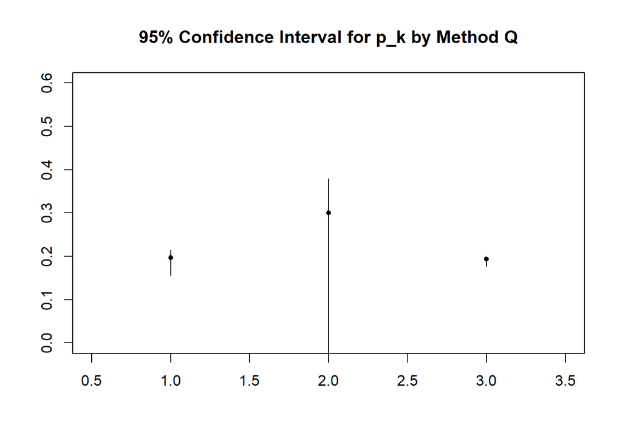

```r
#png(file='A1Q5_plot2.png')
plot(x = c(1,1),y = CI_Q_1000, xlim = c(0.5,3.5),ylim = c(0.0,0.6),main = "95% Confidence Interval for p_k by Method Q",type = 'l',ylab="",xlab="")
lines(x = c(2,2),y = CI_Q_10 )
lines(x = c(3,3),y = CI_Q_10000)
points(1:3,p_k, pch = 20)
```

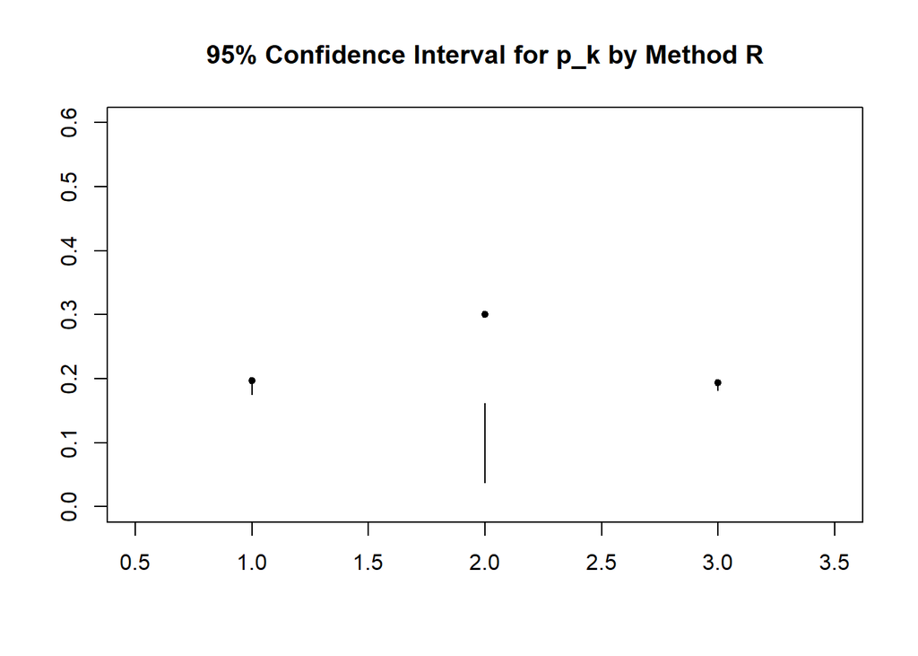

```r
#png(file='A1Q5_plot1.png')
plot(x = c(1,1),y = CI_R_1000, xlim = c(0.5,3.5),ylim = c(0.0,0.6),main = "95% Confidence Interval for p_k by Method R",type = 'l',ylab="",xlab="")
lines(x = c(2,2),y = CI_R_10 )
lines(x = c(3,3),y = CI_R_10000)
points(1:3,p_k, pch = 20)
```

```r
df_R <- data.frame(n = c(1000,10,10000),
                   p_k= p_k,
                 left_point = c(CI_R_1000[1],CI_R_10[1],CI_R_10000[1]),
                 right_point = c(CI_R_1000[2],CI_R_10[2],CI_R_10000[2]))
knitr::kable(df_R)
```

| n | p_k | left_point | right_point |
| --- | --- | --- | --- |
| 1000 | 0.1970 | 0.1756455 | 0.1943545 |
| 10 | 0.3000 | 0.0380194 | 0.1619806 |
| 10000 | 0.1931 | 0.1820445 | 0.1879555 |

```r
# n = 1000
```

```r
df_Q <- data.frame(n = c(1000,10,10000),
                   p_k= p_k,
                   left_point = c(CI_Q_1000[1],CI_Q_10[1],CI_Q_10000[1]),
                   right_point = c(CI_Q_1000[2],CI_Q_10[2],CI_Q_10000[2]))
knitr::kable(df_Q)
```

| n | p_k | left_point | right_point |
| --- | --- | --- | --- |
| 1000 | 0.1970 | 0.1560179 | 0.2142898 |
| 10 | 0.3000 | -0.0425474 | 0.3797024 |
| 10000 | 0.1931 | 0.1762524 | 0.1948226 |

As we can see from the tables and figures above, with n = 10, the two confidence intervals are not comparable. As n = 1000 or 10000, the $p_k$ values are very close, and the confidence intervals are close. However, we still observe this problem is: the estimated $p_k$ values are not located into the 95% confidence interval generated by R estimator although the end of the confidence intervals are very close.

Question 6

```r
#STAT906 Assignment1 Q6

#initialization
#set.seed(906)
mu <- 0.07
sigma <- 0.3
lamda <-1
alpha <- 2
beta <- 0.5

#Q6(a)
S_0 <-100
T <- 0.5
K <- 120
n <-1000
S_T <-rep(0,n)
c <-rep(0,n)
N <-rep(0,n)
W <- rnorm(n,mean = 0, sd = sqrt(T))
for (i in 1:n){
  N[i] <- rpois(1,lamda*T)
  Y <- rgamma(N[i],shape = alpha, scale = beta)
  S_T[i] <- S_0*exp((mu-sigma^2/2)*T+sigma*W[i])*prod(Y)
}
c[S_T > K] <- 1
P <- sum(c)/n
P
```

```
## [1] 0.26
```

```r
sigma_hat <- sqrt(sum((c-P)^2)/(n-1))
CI <- c(P - 1.96*sigma_hat/sqrt(n),P + 1.96*sigma_hat/sqrt(n))
sum <-sum(N ==0)
CI
```

```
## [1] 0.2327996 0.2872004
```

```r
half_width <- (CI[2]-CI[1])/2
half_width
```

```
## [1] 0.02720044
```

```r
# Q6(b)
num_jumps <- sum/n
theoritical_jumps <- 1- exp(-beta)
print(1 - num_jumps)
```

```
## [1] 0.398
```

```r
theoritical_jumps
```

```
## [1] 0.3934693
```

Question 7

```r
#Q7
B <- 1000
p_k_bootstrap <- rep(0,B)
for (i in 1:B){
  c <- rep(0,n)
  indicies <- sample(1:n, replace = T)
  S_T_bootstrap <- S_T[indicies]
  c[S_T_bootstrap > K] <- 1
  p_k_bootstrap[i] <- sum(c)/n
}
p_k_bootstrap_mean <- mean(p_k_bootstrap)
sigma_p_k_bootstrap <- sqrt(sum((p_k_bootstrap - p_k_bootstrap_mean)^2)/(B-1))
CI_bootstrap <- c(p_k_bootstrap_mean-1.96*sigma_p_k_bootstrap/sqrt(B),
                  p_k_bootstrap_mean+1.96*sigma_p_k_bootstrap/sqrt(B))
CI_bootstrap
```

```
## [1] 0.2588545 0.2606015
```

Question 8

```r
#STAT906 Assignment1 Q8

#(a)
r<-0.04
T<-1
sigma<-0.35
S_0<-50
K<-45
s<-2
n <-10000
delta <-T/s
A_T <- rep(0,n)
S_t <- matrix(,nrow = n, ncol = s+1)
S_t[,1] <- S_0
for (i in 1:n){
  #S_t <- rep(S_0,s+1)
  z <- rnorm(2,mean = 0,sd = 1)
  for(j in 2:(s+1)){
    S_t[i,j] = S_t[i,j-1]*exp((r - sigma^2/2)*delta + sigma*sqrt(delta)*z[j-1])
  }
  A_T[i] <- (S_t[i,s] + S_t[i,s+1])/s
}

C_T <- A_T - K
C_T[C_T <0] <- 0
C_0 <- mean(exp(-r*T)*C_T)
C_0
```

```
## [1] 8.632136
```

```r
sigma_hat <- sqrt(sum((exp(-r*T)*C_T - C_0)^2)/(n-1))
CI <- c(C_0 - 1.96*sigma_hat/sqrt(n), C_0 + 1.96*sigma_hat/sqrt(n))
CI
```

```
## [1] 8.413475 8.850797
```

```r
#(b) using Brownian Bridge method
# S_t[2] used to save S_T, S_t[3] used to save S_T/2
A_T_Bb <- rep(0,n)
S_t_Bb <- matrix(,nrow = n, ncol = s+1)

S_t_Bb[,1] <- S_0
for (i in 1:n){
  z <- rnorm(s,mean = 0, sd = 1) # w[1] saves W_T, w[2] saves W_T/2
  #S_t_Bb <- rep(S_0,s+1)
  #print(S_t_Bb)
  for(j in 1:s){
    if(j ==1){
      w<- sqrt(T)*z[j]

    }else{
      w<- z[j]*sqrt(T)/2 + w/2

    }
    S_t_Bb[i,j+1] <- S_t_Bb[i,1]*exp((r - sigma^2/2)*T/j + sigma*w)
  }
  A_T_Bb[i] <- (S_t_Bb[i,s] + S_t_Bb[i,s+1])/s
}

C_T_Bb <- A_T_Bb - K
C_T_Bb[C_T_Bb <0] <- 0
C_0_Bb <- mean(exp(-r*T)*C_T_Bb)
C_0_Bb
```

```
## [1] 8.805438
```

```r
sigma_Bb_hat <- sqrt(sum((exp(-r*T)*C_T_Bb - C_0_Bb)^2)/(n-1))
CI_Bb <-c(C_0_Bb - 1.96*sigma_Bb_hat/sqrt(n),C_0_Bb + 1.96*sigma_Bb_hat/sqrt(n))
CI_Bb
```

```
## [1] 8.579803 9.031073
```

As we see from the obtained data, the price is consistent with both two methods, and the Confidence Interval is very close to each other as well.